# Statistics for Psychologists 3.

**Computer lab 02**

**Course Number:** BTPS2040BA-E  
**Contact Information:** Please contact me through email anytime: abari.kalman@arts.unideb.hu

Author

Kálmán Abari

Published

March 3, 2025

**To earn 1 point**

To earn 1 point, submit all jamovi OMV files in this Computer lab that contain the activities you completed here. The subject of the email should be `Stat3 - Comp. lab 02`. Send the email to `abari.kurzus@gmail.com`.

# Worked Example 1

We asked people about their salary and assessed their job satisfaction using a questionnaire. The sample contains data from only five individuals.

# Step 1.

Let’s **import** the **lin_01.xlsx** file into **Jamovi**.

**Steps to Load the File in Jamovi:**

1. Open **Jamovi**.
2. Click on **“Open”** (📂 icon) in the top-left corner.
3. Select **“Browse”** and locate the **lin_01.xlsx** file.
4. Convert the variable type to continuous in Jamovi.

[figure not shown]

# Step 2.

To perform **Descriptive Statistics** in **Jamovi**, follow these steps:

[figure not shown]

# Step 3.

To perform **Correlation Analysis** in **Jamovi**, follow these steps:

1. **Open Jamovi** and load your dataset (e.g., *lin_reg_01*).
2. Click on the **“Analyses”** tab in the top menu.
3. Select **“Regression” → “Correlation Matrix”**.
4. In the **Variables** section, move the variables you want to analyze (e.g., *salary* and *job_satisfaction*) into the right panel.
5. Under **Correlation Coefficients**, select:
   - **Pearson** (for linear relationships).
6. Under **Additional Options**, enable:
   - **Report significance** (to display p-values).
   - **Flag significant correlations** (optional).
   - **N** (sample size, optional).
   - **Confidence intervals** (set at **95%**, optional).
7. Under **Plot**, check:
   - **Correlation matrix** (for visual representation).
   - **Densities for variables** (optional for distribution visualization).
8. The **Results panel** will display:
   - A **correlation matrix** showing Pearson’s rr values.
   - The **degrees of freedom (df)** and **p-values** to test statistical significance.
   - A **scatter plot** to visualize the relationship.

**Interpretation:**

- A **Pearson correlation of 1.00** indicates a **perfect positive correlation** between salary and job satisfaction.
- The **p-value (<0.0001)** suggests that the correlation is **highly significant**.

[figure not shown]

# Step 4

[figure not shown]

To conduct **Linear Regression** in **Jamovi**, follow these steps:

#### **1. Open Jamovi and Load Your Dataset**

- Click on the **“Analyses”** tab in the top menu.
- Select **“Regression” → “Linear Regression”**.

#### **2. Select Variables**

- Move the **dependent variable** (e.g., *job_satisfaction*) into the **Dependent Variable** box.
- Move the **independent variable** (e.g., *salary*) into the **Covariates** box.

#### **4. Interpretation**

- A **high t-value (70.77)** and **low p-value (< 0.0001)** suggest that salary has a strong effect on job satisfaction.
- The **scatter plot** confirms a strong linear relationship.

#### **5. Additional Options** (Optional)

- Expand **Assumption Checks** to verify normality and homoscedasticity.
- Expand **Model Coefficients** to add confidence intervals.

# Worked Example 2

We asked people about their salary and assessed their job satisfaction using a questionnaire. The sample contains data from only five individuals, and we also collected information about their age.

# Step 1.

Let’s **import** the **lin_02.xlsx** file into **Jamovi**.

**Steps to Load the File in Jamovi:**

[figure not shown]

# Step 2

### **Steps to Perform Multiple Linear Regression in Jamovi**

#### **1. Open Jamovi and Load the Dataset**

- Click on the **“Analyses”** tab in the top menu.
- Select **“Regression” → “Linear Regression”**.

#### **2. Select Variables**

- Move **job_satisfaction** to the **Dependent Variable** box.
- Move **salary** and **age** to the **Covariates** box.

#### **3. Interpret the Model Fit Measures**

- The **R2=1.00** means that the independent variables explain **100% of the variance** in job satisfaction.

#### **4. Interpret the Model Coefficients**

- **Intercept (b_0 = 21.51)**: The predicted job satisfaction when both salary and age are zero.
- **Salary (b_1 = 0.52, p=0.0003)**: A **positive significant** predictor—higher salary increases job satisfaction.
- **Age (b_2 = -0.31, p=0.0058)**: A **negative significant** predictor—higher age is associated with lower job satisfaction.

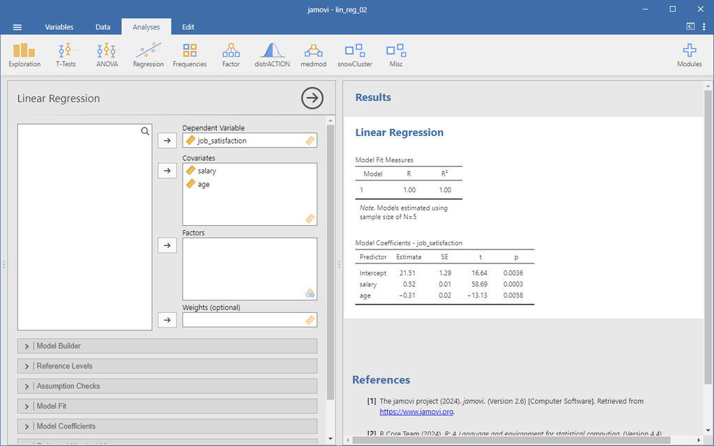

A **multiple linear regression analysis** was performed with **job satisfaction** as the dependent variable and **salary** and **age** as independent variables. The model shows an **R^2 value of 1.00**, meaning **100% of the variance** in job satisfaction is explained by the predictors.

- **Salary (b1=0.52)** has a **positive and significant** effect on job satisfaction (p = 0.0003), meaning higher salary is associated with greater satisfaction.
- **Age (b2=−0.31)** has a **negative and significant** effect (p = 0.0058), suggesting that as age increases, job satisfaction decreases.

This analysis suggests that **both salary and age significantly influence job satisfaction**, but in **opposite directions**.